# Project 3: Investigate a Dataset (NoShowAppointments)

- Introduction
- Data Wrangling
- Exploratory Data Analysis
- Conclusions

## Introduction

### Overview

> In this project I will be going through the entire data analysis process which include, Asking Questions, Wrangle, Explore(EDA), Draw Conclusion and Communicate critical findings

> The analysis process always starts with asking questions. In this project, I have been given a data set so I will glance through the data and pose some relevant questions.

> To complete this Data Analysis project I will be using the NoShowAppointments dataset.

### Questions:

> 1. What is the overall appointment show-up vs. no show-up rate?
> 2. Does alcoholism affect patient's show up?
> 3. Does patients with diabetes show up more than the ones without diabetes?
> 4. Does people who have scholarship show up more?
> 5. What is the proportions of sms received?
> 6. Does sms received affect appointment show rate?
> 7. Which location has the most appointment show rate?

> **Dataset**: This dataset collects information from 100k medical appointments in Brazil and is focused on the question of whether or not patients show up for their appointment. It can be downloaded from [here](https://d17h27t6h515a5.cloudfront.net/topher/2017/October/59dd2e9a_noshowappointments-kagglev2-may-2016/noshowappointments-kagglev2-may-2016.csv).

## Data Dictionary

**01 PatientId** Identification of a patient

**02 - AppointmentID**

Identification of each appointment

**03 - Gender** Male or Female

**04 - ScheduledDay** The day someone called or registered the appointment, this is before appointment of course.

**05 - AppointmentDay** The day of the actuall appointment, when they have to visit the doctor.

**06 - Age** How old is the patient.

**07 - Neighbourhood** Where the appointment takes place.

**08 - Scholarship** True of False . Observation, this is a broad topic, consider reading this article [here](https://en.wikipedia.org/wiki/Bolsa_Fam%C3%ADlia)

**09 - Hipertension** True or False

**10 - Diabetes** True or False

**11 - Alcoholism** True or False

**12 - Handcap** True or False

**13 - SMS_received** 1 or more messages sent to the patient.

**14 - No-show** True or False.

```python
# First and foremost, lets import libraries that we shall usein this project
import pandas as pd
import numpy as np
# from datetime import datetime as dt
import matplotlib.pyplot as plt
%matplotlib inline
import seaborn as sns
sns.set_style('darkgrid')
```

## Data Wrangling

> Here I will load in the dataset, and use Pandas to explore some helpful methods for assessing and building intuition about the dataset, then I will proceed with the cleaning process to include only the relavent data related to the questions I will investigate delete the unused data.

### General Properties

```python
# loading data
df=pd.read_csv('noshowappointments-kagglev2-may-2016.csv')
# show number of rows and columns
print(df.shape)

# show first 2 rows
df.head(2)
```

```
(110527, 14)
```

|  | PatientId | AppointmentID | Gender | ScheduledDay | AppointmentDay | Age | Neighbourhood | Scholarship | Hipertension | Diabetes | Alcoholism | Handcap | SMS_received | No-show |
| --- | --- | --- | --- | --- | --- | --- | --- | --- | --- | --- | --- | --- | --- | --- |
| 0 | 2.987250e+13 | 5642903 | F | 2016-04-29T18:38:08Z | 2016-04-29T00:00:00Z | 62 | JARDIM DA PENHA | 0 | 1 | 0 | 0 | 0 | 0 | No |
| 1 | 5.589978e+14 | 5642503 | M | 2016-04-29T16:08:27Z | 2016-04-29T00:00:00Z | 56 | JARDIM DA PENHA | 0 | 0 | 0 | 0 | 0 | 0 | No |

```python
# lets take a look at the columns names more closely
for i,v in enumerate(df.columns):
    print(i, v)
```

```
0 PatientId
1 AppointmentID
2 Gender
3 ScheduledDay
4 AppointmentDay
5 Age
6 Neighbourhood
7 Scholarship
8 Hipertension
9 Diabetes
10 Alcoholism
11 Handcap
12 SMS_received
13 No-show
```

> **Initial observation**:
> - Our focus will be analyzing properties important in order to predict if a patient will show up for their scheduled appointment? some columns are irrelavant for our analysis, e.g `PatientId`, and `AppointmentID`

```python
# check the dimensions of the dataset
df.shape
```

```
(110527, 14)
```

```python
# check for data type and missing values
df.info()
```

```
<class 'pandas.core.frame.DataFrame'>
RangeIndex: 110527 entries, 0 to 110526
Data columns (total 14 columns):
 #   Column          Non-Null Count   Dtype
---  ------          --------------   -----
 0   PatientId       110527 non-null  float64
 1   AppointmentID   110527 non-null  int64
 2   Gender          110527 non-null  object
 3   ScheduledDay    110527 non-null  object
 4   AppointmentDay  110527 non-null  object
 5   Age             110527 non-null  int64
 6   Neighbourhood   110527 non-null  object
 7   Scholarship     110527 non-null  int64
 8   Hipertension    110527 non-null  int64
 9   Diabetes        110527 non-null  int64
 10  Alcoholism      110527 non-null  int64
 11  Handcap         110527 non-null  int64
 12  SMS_received    110527 non-null  int64
 13  No-show         110527 non-null  object
dtypes: float64(1), int64(8), object(5)
memory usage: 11.8+ MB
```

```python
# check for missing values
df.isnull().sum().any()
```

```
False
```

> - Interestingly enough, the dataset has zero null value

```python
# check statistical information
df.describe()
```

|  | PatientId | AppointmentID | Age | Scholarship | Hipertension | Diabetes | Alcoholism | Handcap | SMS_received |
| --- | --- | --- | --- | --- | --- | --- | --- | --- | --- |
| count | 1.105270e+05 | 1.105270e+05 | 110527.000000 | 110527.000000 | 110527.000000 | 110527.000000 | 110527.000000 | 110527.000000 | 110527.000000 |
| mean | 1.474963e+14 | 5.675305e+06 | 37.088874 | 0.098266 | 0.197246 | 0.071865 | 0.030400 | 0.022248 | 0.321026 |
| std | 2.560949e+14 | 7.129575e+04 | 23.110205 | 0.297675 | 0.397921 | 0.258265 | 0.171686 | 0.161543 | 0.466873 |
| min | 3.921784e+04 | 5.030230e+06 | -1.000000 | 0.000000 | 0.000000 | 0.000000 | 0.000000 | 0.000000 | 0.000000 |
| 25% | 4.172614e+12 | 5.640286e+06 | 18.000000 | 0.000000 | 0.000000 | 0.000000 | 0.000000 | 0.000000 | 0.000000 |
| 50% | 3.173184e+13 | 5.680573e+06 | 37.000000 | 0.000000 | 0.000000 | 0.000000 | 0.000000 | 0.000000 | 0.000000 |
| 75% | 9.439172e+13 | 5.725524e+06 | 55.000000 | 0.000000 | 0.000000 | 0.000000 | 0.000000 | 0.000000 | 1.000000 |
| max | 9.999816e+14 | 5.790484e+06 | 115.000000 | 1.000000 | 1.000000 | 1.000000 | 1.000000 | 4.000000 | 1.000000 |

> **Insights**:
> - Both ScheduledDay and AppointmentDay column do not have correct data type. We shall convert them to datetime object.
> - We shall also corect the speling of `Handcap` and `Hipertention` and replace the hephen (-) in `No-show` column label with underscore (_)
> - The minimum `Age` is -1 , which is impossible, we will investigate this further in our analysis

### Data Cleaning

> 1. drop duplicate data
> 2. drop columns which are not necessary for this analysis.
> 3. apply column names to lower case.
> 4. correct column names.
> 5. change no-show column to showed to avoid confusion.
> 6. datetime formatting.
> 7. delete rows with wrong values (age less than 0).
> 8. add some important features to the data such as month of the appointment

**1. Remove duplicated data**

```python
# check how many rows are duplicated
sum(df.duplicated())
```

```
0
```

```python
# Drop duplicated rows
df.drop_duplicates(inplace=True)

# douch check the results
sum(df.duplicated())
```

```
0
```

**2. Drop columns which are not necessary for this analysis.**

```python
# Drop extraneous columns
drop_col=['PatientId','AppointmentID']
df = df.drop(drop_col, axis=1)
# check the result
df.head(3)
```

|  | Gender | ScheduledDay | AppointmentDay | Age | Neighbourhood | Scholarship | Hipertension | Diabetes | Alcoholism | Handcap | SMS_received | No-show |
| --- | --- | --- | --- | --- | --- | --- | --- | --- | --- | --- | --- | --- |
| 0 | F | 2016-04-29T18:38:08Z | 2016-04-29T00:00:00Z | 62 | JARDIM DA PENHA | 0 | 1 | 0 | 0 | 0 | 0 | No |
| 1 | M | 2016-04-29T16:08:27Z | 2016-04-29T00:00:00Z | 56 | JARDIM DA PENHA | 0 | 0 | 0 | 0 | 0 | 0 | No |
| 2 | F | 2016-04-29T16:19:04Z | 2016-04-29T00:00:00Z | 62 | MATA DA PRAIA | 0 | 0 | 0 | 0 | 0 | 0 | No |

**3. Cleaning abnormal data for the Age column**

```python
# Find out how many rows are 0 for runtime
sum(df["Age"] <= 0)
```

```
3540
```

```python
# Since it is impossible to have Age as 0 or less, we will remove these.
df = df[df["Age"] > 0]

#double check the result
sum(df["Age"] <= 0)
```

```
0
```

**4. Correct column names**

```python
df = df.rename(columns={'Hipertension':'Hypertension', 'Handcap':'Handicap', 'No-show':'Showed'})
```

```python
# check for columns labels again
df.columns
```

```
Index(['Gender', 'ScheduledDay', 'AppointmentDay', 'Age', 'Neighbourhood',
       'Scholarship', 'Hypertension', 'Diabetes', 'Alcoholism', 'Handicap',
       'SMS_received', 'Showed'],
      dtype='object')
```

```python
# It's generally considered best practice according to PEP 8 that variable names are lowercase
# with underscore separating multiple words.
```

**5. Let's change the column names to lower case to comply with the PEP8 as stated above**

```python
labels = []
for item in df.columns:
    item = item.lower()
    if 'day' in item:
        labels.append(item[:-3] + '_day')
    else:
        labels.append(item)
labels
```

```
['gender',
 'scheduled_day',
 'appointment_day',
 'age',
 'neighbourhood',
 'scholarship',
 'hypertension',
 'diabetes',
 'alcoholism',
 'handicap',
 'sms_received',
 'showed']
```

```python
# lets set the columns labels equals to the labels that we just created above
df.columns = labels
df.columns
```

```
Index(['gender', 'scheduled_day', 'appointment_day', 'age', 'neighbourhood',
       'scholarship', 'hypertension', 'diabetes', 'alcoholism', 'handicap',
       'sms_received', 'showed'],
      dtype='object')
```

**6. Let's change the data types of `scheduled_day` and `appointment_day` columns to datetime object**

```python
cols = df.columns[1:3]
df[cols] = df[cols].apply(pd.to_datetime, errors='coerce')
#let's check again the data types of our column labels
df.dtypes
```

```
gender                          object
scheduled_day      datetime64[ns, UTC]
appointment_day    datetime64[ns, UTC]
age                              int64
neighbourhood                   object
scholarship                      int64
hypertension                     int64
diabetes                         int64
alcoholism                       int64
handicap                         int64
sms_received                     int64
showed                          object
dtype: object
```

```python
# Let's add the following features scheduledhour, scheduleddayofweek,
# scheduledmonth, scheduledyear, appointmentdayofweek, appointmentmonth, appointmentyear
df['scheduledhour'] = df['scheduled_day'].dt.hour
df['scheduleddayofweek'] = df['scheduled_day'].dt.day_name()
df['scheduledmonth'] = df['scheduled_day'].dt.month_name()
df['scheduledyear'] = df['scheduled_day'].dt.year
df['appointmentdayofweek'] = df['appointment_day'].dt.day_name()
df['appointmentmonth'] = df['appointment_day'].dt.month_name()
df['appointmentyear'] = df['appointment_day'].dt.year
```

**7. let us convert showed data to 0 and 1 instead of 'yes' and 'no' so we can handle using plot and/or goupby**

```python
df['showed'] = df['showed'].apply(lambda x: 1 if x =='No' else 0 )
df['showed'].value_counts()
```

```
1    85307
0    21680
Name: showed, dtype: int64
```

```python
# Finally let us create a mask for people who showed up
# showed = df.no_show == 0
# not_showed = df.no_show == 1
```

```python
# View the first five rows in our data set
df.head()
```

|  | gender | scheduled_day | appointment_day | age | neighbourhood | scholarship | hypertension | diabetes | alcoholism | handicap | sms_received | showed | scheduledhour | scheduleddayofweek | scheduledmonth | scheduledyear | appointmentdayofweek | appointmentmonth | appointmentyear |
| --- | --- | --- | --- | --- | --- | --- | --- | --- | --- | --- | --- | --- | --- | --- | --- | --- | --- | --- | --- |
| 0 | F | 2016-04-29 18:38:08+00:00 | 2016-04-29 00:00:00+00:00 | 62 | JARDIM DA PENHA | 0 | 1 | 0 | 0 | 0 | 0 | 1 | 18 | Friday | April | 2016 | Friday | April | 2016 |
| 1 | M | 2016-04-29 16:08:27+00:00 | 2016-04-29 00:00:00+00:00 | 56 | JARDIM DA PENHA | 0 | 0 | 0 | 0 | 0 | 0 | 1 | 16 | Friday | April | 2016 | Friday | April | 2016 |
| 2 | F | 2016-04-29 16:19:04+00:00 | 2016-04-29 00:00:00+00:00 | 62 | MATA DA PRAIA | 0 | 0 | 0 | 0 | 0 | 0 | 1 | 16 | Friday | April | 2016 | Friday | April | 2016 |
| 3 | F | 2016-04-29 17:29:31+00:00 | 2016-04-29 00:00:00+00:00 | 8 | PONTAL DE CAMBURI | 0 | 0 | 0 | 0 | 0 | 0 | 1 | 17 | Friday | April | 2016 | Friday | April | 2016 |
| 4 | F | 2016-04-29 16:07:23+00:00 | 2016-04-29 00:00:00+00:00 | 56 | JARDIM DA PENHA | 0 | 1 | 1 | 0 | 0 | 0 | 1 | 16 | Friday | April | 2016 | Friday | April | 2016 |

## Exploratory Data Analysis

### Research Question 1. (what is the overall appointment show-up vs. no show-up rate?)

###### Make a pie chart to display the percentage of patients who showed up and who didn't

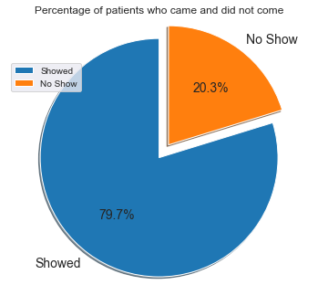

```python
showed_noshowed = df['showed'].value_counts()
percentage_showed_noshowed = (showed_noshowed[1] / showed_noshowed.sum() * 100, showed_noshowed[0] / showed_noshowed.sum() * 100)
mylabels = ['Showed', 'No Show']

plt.axis('equal') #It helps to equalize the circular dimensions
plt.pie(percentage_showed_noshowed,labels=mylabels,radius=1.5,shadow=True,explode=(0,0.2),autopct='%1.1f%%',startangle= 90,textprops = {"fontsize":14})
plt.title('Percentage of patients who came and did not come',y=1.2)
plt.legend()
plt.show()
```

> - The proportion of patients who came to their appointment is 79.7%
> - Percentage of patients who did not attend their appointment is 20.3%

```python
df['sms_received'].value_counts()
```

```
0    72402
1    34585
Name: sms_received, dtype: int64
```

### **Research Question: Does alcoholism affect patient's show up?**

#### Let us define a function which we shall reuse to avoid repetitive code

```python
def proportion_func(df,my_list,col_name):
    """
    This function calculates proportions for specific column by using pandas value_counts() and groupby()
    and returns the proportions if all input data are correct.
    It prints nice message to the user should bad input be supplied.

    Input:
    - df : dataframe which contains all patients who showed up and didn't not show up for an appointment
    - my_list : This list contains column names that we need to groupby (groupby will be sorted the same way as my_list value sort)
    - col_name : column name (which we want to calculate proportion according to it)
    Output:
    - proportion : It's a pandas Series that contains grouped by my_list values and proportions according to col_name
    """
    try:
        if df.empty:
            raise Exception('dataframe is empty')
        for item in my_list:
            if item not in df:
                raise Exception('one or more columns in my_list are not part of the dataframe')
        proportion = df.groupby(my_list)[col_name].value_counts(normalize=True).unstack(col_name)
        return proportion
    except Exception as error:
        print("You have entered bad input " + repr(error))
```

**Now I'm going to use proportions_fun to calculate proportions for each factor trying to find correlations**

```python
prop_alcoholism = proportion_func(df,['alcoholism'],'showed')
prop_alcoholism
```

| showed alcoholism | 0 | 1 |
| --- | --- | --- |
| 0 | 0.202679 | 0.797321 |
| 1 | 0.201488 | 0.798512 |

> - Alcoholic and non-alcoholic patients have approximated the same show up rate to appointment at 80%

**Let us vizualize our findings below**

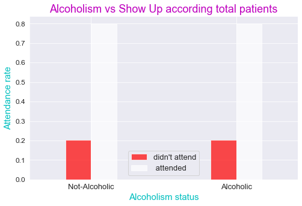

```python
# Bar chart showed Alcoholic and not-Alcoholic proportions

prop_alcoholism.plot(kind = "bar",
                            rot = 0,
                            width = 0.35,
                            color=["red","white"],
                            alpha = 0.7,
                            fontsize = 12,
                            figsize=(8,5)
                             )

plt.ylabel("Attendance rate",fontsize=15, color="c")
plt.xlabel("Alcoholism status",fontsize=15, color="c")
plt.title("Alcoholism vs Show Up according total patients", fontsize=18, color="m")
labels = ["Not-Alcoholic","Alcoholic"]
plt.xticks(range(len(labels)),labels, fontsize=13);
plt.legend(["didn't attend"," attended"],fontsize=13);
```

> - Alcoholism has no direct correlation with attendance.

### **Research Question: Does patients with diabetes show up more than the ones without diabetes?**

```python
prop_diabetes = proportion_func(df,['diabetes'],'showed')
prop_diabetes
```

| showed diabetes | 0 | 1 |
| --- | --- | --- |
| 0 | 0.204455 | 0.795545 |
| 1 | 0.180033 | 0.819967 |

> - Patients with diabetes had slightly higer show up rate at 81% that patients without at 80%.

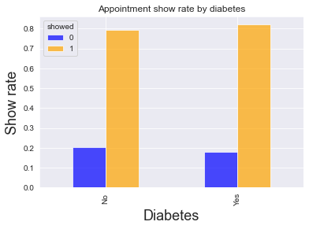

```python
# show rate bar chart with diabetes

prop_diabetes.plot(kind='bar', alpha=.7, color=['blue', 'orange']);

# title and labels
plt.xticks([0, 1], ['No', 'Yes'])
plt.title('Appointment show rate by diabetes');
plt.ylabel('Show rate', fontsize=18)
plt.xlabel('Diabetes', fontsize=18);
```

> - We can conclude that diabetes has no direct or strong correlation with attendance

## **Research Question: Does people who have scholarship show up more?**

```python
prop_scholar = proportion_func(df,['scholarship'], 'showed')
prop_scholar
```

| showed scholarship | 0 | 1 |
| --- | --- | --- |
| 0 | 0.198684 | 0.801316 |
| 1 | 0.237857 | 0.762143 |

> - People with no scholarship have a slightly higher show-up rate to medical appointments at 80% that people with scholarship at 76%.

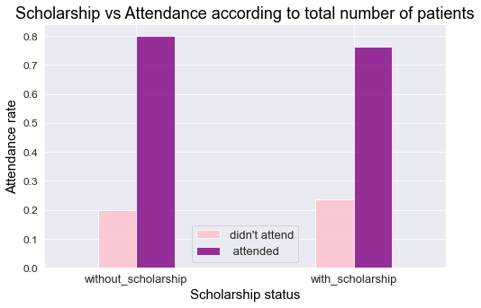

```python
prop_scholar.plot(kind = "bar",
                               rot = 0,
                               width = 0.35,
                               color=["pink","purple"],
                               alpha = 0.8,
                               fontsize = 12,
                               figsize=(8,5)
                                 )
plt.ylabel("Attendance rate",fontsize=15, color="k")
plt.xlabel("Scholarship status",fontsize=15, color="k")
plt.title("Scholarship vs Attendance according to total number of patients", fontsize=18, color="k")
labels = ['without_scholarship', 'with_scholarship']
plt.xticks(range(len(labels)),labels, fontsize=13);
plt.legend(["didn't attend"," attended"],fontsize=13);
```

> - People with no scholarship have a slightly higher show-up rate to medical appointments as showed on the chart above.

### **Research Question: What is the proportions of sms received?**

```python
prop_sms = df.sms_received.value_counts(normalize=True)
prop_sms
```

```
0    0.676736
1    0.323264
Name: sms_received, dtype: float64
```

> - About 32% of the patients received sms while 68% did not

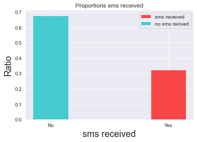

```python
sms_bar = plt.bar(1, prop_sms[1], width=.3, alpha=0.7, color ='r', label='sms received' )
no_sms_bar = plt.bar(0, prop_sms[0], width=.3, alpha=0.7, color='c', label='no sms recived')

# title and labels
plt.xticks([0, 1], ['No', 'Yes'])
plt.xlabel('sms received', fontsize=18)
plt.ylabel('Ratio', fontsize=18)
plt.title('Proportions sms received');
plt.legend();
```

> - We can conclude that there were more patients that did not receive sms than those who did

### **Research Question: Does sms received affect appointment show rate?**

```python
prop_sms_received = proportion_func(df,['sms_received'], 'showed')
prop_sms_received
```

| showed sms_received | 0 | 1 |
| --- | --- | --- |
| 0 | 0.167288 | 0.832712 |
| 1 | 0.276652 | 0.723348 |

> - Receiving sms appears to be ineffective to improve the medical appointment show up rate with patients that did not receive sms having higher show up rate at 83% than patients that received at 72%.

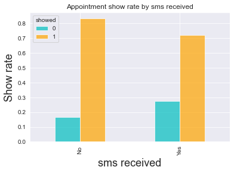

```python
# show rate bar chart with sms received

prop_sms_received.plot(kind='bar', alpha=.7, color=['c', 'orange']);

# title and labels
plt.xticks([0, 1], ['No', 'Yes'])
plt.title('Appointment show rate by sms received');
plt.xlabel('sms received', fontsize=18)
plt.ylabel('Show rate', fontsize=18);
```

> - Receiving sms does not improve the patients appointment show up rate. In fact patients who did not receive sms had higher show up rate which is a bit weird

### **Research Question: Which gender has the most appointment show rate?**

```python
prop_gender = proportion_func(df,['gender'],'showed')
prop_gender
```

| showed gender | 0 | 1 |
| --- | --- | --- |
| F | 0.203585 | 0.796415 |
| M | 0.200846 | 0.799154 |

> - With respect to gender there is no differnece in the show up rate to appointment.

**Let us vizualize our findings below**

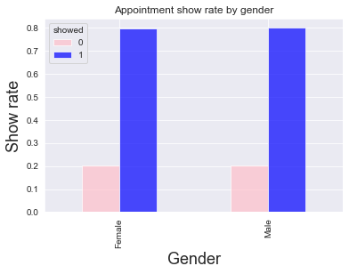

```python
# show rate bar chart by gender

prop_gender.plot(kind='bar', alpha=.7, color=['pink', 'blue']);

# title and labels
plt.xticks([0, 1], ['Female', 'Male'])
plt.title('Appointment show rate by gender');
plt.xlabel('Gender', fontsize=18)
plt.ylabel('Show rate', fontsize=18);
```

> - It doesn't seem like gender influence patients' show up.

### **Research Question: Which year had the most appointment?**

```python
df.appointmentyear.value_counts()
```

```
2016    106987
Name: appointmentyear, dtype: int64
```

> - It looks like all the appointments were made in the year 2016

### **Research Question: Which month in 2016 had the most appointment proportion?**

```python
df.appointmentmonth.value_counts()
```

```
May      78202
June     25681
April     3104
Name: appointmentmonth, dtype: int64
```

> - The month of May in 2016 had recorded the most appointments

**Lets vizualize our result below**

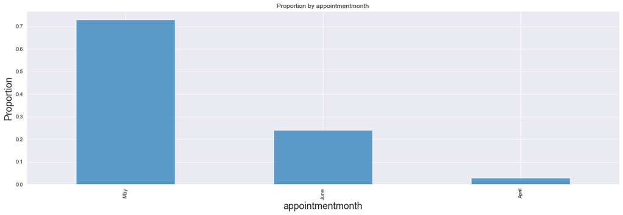

```python
# show bar chart with appointmentmonth proportions
plt.figure(figsize = (20,6));
df['appointmentmonth'].value_counts(normalize = True).sort_values(ascending=False).plot(kind='bar', alpha=.7);

# title and labels

plt.ylabel('Proportion', fontsize=18)
plt.xlabel('appointmentmonth', fontsize=18)
plt.title('Proportion by appointmentmonth');
```

> - The above chart corroborates our finding that the most of May in 2016 had the highest appointment

### **Research Question: Which location has the most appointments?**

```python
# selecting where the appointment took place in the data
df['neighbourhood'].value_counts().sort_values(ascending=False)
```

```
JARDIM CAMBURI                 7586
MARIA ORTIZ                    5563
RESISTÊNCIA                    4235
JARDIM DA PENHA                3851
ITARARÉ                        3412
                               ...
ILHA DO BOI                      35
ILHA DO FRADE                    10
AEROPORTO                         8
ILHAS OCEÂNICAS DE TRINDADE       2
PARQUE INDUSTRIAL                 1
Name: neighbourhood, Length: 81, dtype: int64
```

> - JARDIM CAMBURI is the location that had the most appointments

```python
# select the location of the appointment and get its average
df['neighbourhood'].value_counts(normalize = True).sort_values(ascending=False)
```

```
JARDIM CAMBURI                 0.070906
MARIA ORTIZ                    0.051997
RESISTÊNCIA                    0.039584
JARDIM DA PENHA                0.035995
ITARARÉ                        0.031892
                                 ...
ILHA DO BOI                    0.000327
ILHA DO FRADE                  0.000093
AEROPORTO                      0.000075
ILHAS OCEÂNICAS DE TRINDADE    0.000019
PARQUE INDUSTRIAL              0.000009
Name: neighbourhood, Length: 81, dtype: float64
```

> - JARDIM CAMBURI, MARIA ORTIZ and RESISTÊNCIA are locations with most proportions while AEROPORTO, ILHAS OCEÂNICAS DE TRINDADE and PARQUE INDUSTRIAL are locations with least proportions.

**Let us vizualize our findings below**

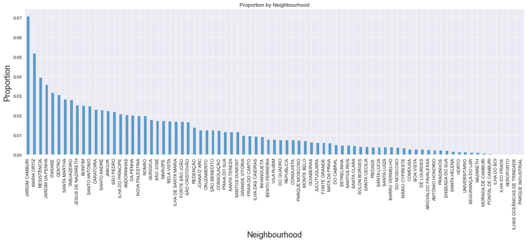

```python
# show bar chart with neighbourhood proportions
plt.figure(figsize = (20,6));
df['neighbourhood'].value_counts(normalize = True).sort_values(ascending=False).plot(kind='bar', alpha=.7);

# title and labels

plt.ylabel('Proportion', fontsize=18)
plt.xlabel('Neighbourhood', fontsize=18)
plt.title('Proportion by Neighbourhood');
```

> - JARDIM CAMBURI is the location with the highest proportion while PARQUE INDUSTRIAL is the location with the least proportion